# Exploratory Analysis: Text Prediction with R

Venkadeshwaran K

June 1, 2016

Summary:

The project to build to model that predicts the text for automatic completion in mobile devices. The data has been acquired from the SwiftKey, Global Leader in text Prediction. The data can be downloaded [here](https://d396qusza40orc.cloudfront.net/dsscapstone/dataset/Coursera-SwiftKey.zip). This report covers the initial modules of the data product developments as listed below.

1. Download and loaded the data
2. Provides the basic report of summary of the dataset.
3. Building the n-gram model and Reporting the interseting finding.
4. Forecasting the plan to build the data product in shinyApp.

## Data Acquisition

The setup.R will create a project dectory in your local system. The data has been downloaded from [here](https://d396qusza40orc.cloudfront.net/dsscapstone/dataset/Coursera-SwiftKey.zip) and extracted into the `data/raw` directory. Here we are concentrating only on the en_US files. So we can deleted the others language files.

```r
list.files('.', recursive = T)
```

```
##  [1] "blogs_tdm_2gram.RDS"        "blogs_tdm_unigram.RDS"
##  [3] "data/raw/en_US.blogs.txt"   "data/raw/en_US.news.txt"
##  [5] "data/raw/en_US.twitter.txt" "data/sample/blogs.txt"
##  [7] "data/sample/news.txt"       "data/sample/twitter.txt"
##  [9] "data/swearWords.csv"        "data/swearWords.txt"
## [11] "data/twitter.RDS"           "main.R"
## [13] "milestone.Rmd"              "news_tdm_2gram.RDS"
## [15] "news_tdm_unigram.RDS"       "setup.R"
## [17] "twitter.txt"                "twitter_tdm_2gram.RDS"
## [19] "twitter_tdm_unigram.RDS"
```

### R packages

The below mentioned packages are necessary to simulate the below experiment. Kindly install and load the needed libraries.

```r
library(tm) # Textmining package
library(SnowballC) # For stemming words
library(dplyr) ## For sorting the word freqency
library(ggplot2) ## For ploting
library(gridExtra) ## for arranging ggplots
library(RWeka) ## For adding ngram tokenization
library(ngram) ## For wordcount
library(slam) ## To perform rowsums on tdm effeciently
```

### Loading Data

We can load the three files (Twitter, News, blogs) into our system to perform some intitial analysis.

```r
raw_files <- list.files('./data/raw/', full.names = T)

f_summary <- function(filelist){
    file_summary <- data.frame(c(0,0,0,0))
    for(i in filelist){
        f <- readLines(i)
        fs <- format(object.size(f), unit = 'MB')
        fl <- length(f)
        fw <- wordcount(f)
        fc <- sum(nchar(f))
        file_summary[,i] <- c(fs, fl, fw, fc)
        rm(f, fs, fl, fw, fc)
    }
    file_summary <- file_summary[,-1]
    colnames(file_summary) <- c('Blogs', 'News', 'Twitter')
    row.names(file_summary) <- c('Object Size in R', 'Line Count', 'Word Count', 'Char Count')
    return(file_summary)

}

raw_file_summary <- f_summary(raw_files)
raw_file_summary
```

```
##                      Blogs     News   Twitter
## Object Size in R  248.5 Mb  19.2 Mb  301.4 Mb
## Line Count          899288    77259   2360148
## Word Count        37334131  2643969  30373543
## Char Count       208361438 15683765 162384825
```

### Data Sampling

As the dataset is very huge, we can take the 10% sample of the totat dataset for building our model. In this model, we will be using binomial distribution to pick the same data. The sample data will be placed in the `./data/sample` directory

```r
set.seed(270891)
for (i in raw_files){
    con <- file(i,'r')
    filename <- unlist(strsplit(i, '[/]'))[4]
    name <- unlist(strsplit(filename, '[.]'))[2]
    temp <- readLines(con)
    len <- length(temp)
    temp1 <- temp[as.logical(rbinom(len, 1, .10))] ## Sampling only 10% of the records
    assign(name, temp1)
    rm(temp, temp1) ## To save system memory
    close(con)
}
## Writing the sample data for future reference
write(news, './data/sample/news.txt')
write(blogs, './data/sample/blogs.txt')
write(twitter, './data/sample/twitter.txt')
```

Here is the summary of the sample data.

```r
sample_files <- list.files('./data/sample/', full.names = T)
sample_file_summary <- f_summary(sample_files)
sample_file_summary
```

```
##                     Blogs    News  Twitter
## Object Size in R  24.8 Mb    2 Mb  30.4 Mb
## Line Count          89850    7947   235916
## Word Count        3729795  272756  3032793
## Char Count       20820943 1615346 16212469
```

## Preprocessing NGram matrix

We have the sample records ready to convert into the ngram matrix. The character vector needs to be preprocessed. As the part of it, we need to remove the profanity words from the vector. The list of profanity words has been collected which can be found [here](https://github.com/venkadeshwarank/Capstone/blob/master/milestone/swearWords.csv).

```r
profanity <- read.csv('./data/swearWords.csv', header = F, stringsAsFactors = F)
profanity <- profanity$V1
```

The below `make_tdm` function takes vector as input and gives the `TermDocumentMatrix` as output. The vector sample will be first converted into VCorpse data type. Then we need to preprocess the data to remove punctuations, numbers, special characters, stop words and the profanity words. The resultant `TermDocumentMatrix` with the required number of n grams.

```r
make_tdm <- function(x, ng=1, stopword = TRUE ){

    corp <- Corpus(VectorSource(x))

    corp <- tm_map(corp, tolower) # To transform all the char to lowercase
    corp <- tm_map(corp, removePunctuation) ## To remove punctuation
    corp <- tm_map(corp, function(x) gsub("[^[:alnum:]]", " ", x)) # To remove special chars
    corp <- tm_map(corp, removeNumbers) ## Numbers provides less value to predective text analysis
    corp <- tm_map(corp, removeWords, profanity) ## To remove swearwords

    if(stopword) {
        corp <- tm_map(corp, removeWords, stopwords()) ##default language is English
    }

    corp <- tm_map(corp, stemDocument) ## Stemming the document
    corp <- tm_map(corp, stripWhitespace) ## To stripwhite space
    corp <- tm_map(corp, PlainTextDocument) ## Converting to plaintext format

    ngt <- function(x) NGramTokenizer(x,control = Weka_control(min=ng, max=ng))
    tdm <- TermDocumentMatrix(corp, control = list(tokenize= ngt))

    return(tdm)
}
```

### Uni-Gram tokenization

```r
news_tdm_unigram <- make_tdm(news)
blogs_tdm_unigram <- make_tdm(blogs)
twitter_tdm_unigram <- make_tdm(twitter)
```

## Explotary Analysis

The words that occurs more than 10,000 times in the twitter can be seen here.

```r
findFreqTerms(twitter_tdm_unigram, 10000)
```

```
## [1] "get"  "just" "like" "love"
```

Lets create a frequency table for each corpse to do more further analysis on this.

```r
freq_table <- function(tdm){
    temp <- row_sums(tdm)
    df <- as.data.frame(temp)
    df$Words <- row.names(df)
    names(df) <- c('Frequency','Words')
    rownames(df) <- NULL
    df <- df %>% transform(Words = reorder(Words, Frequency)) %>%
            arrange(desc(Frequency))
    rm(temp)
    return(df)
}

news_uni_freq <- freq_table(news_tdm_unigram)
blogs_uni_freq <- freq_table(blogs_tdm_unigram)
twitter_uni_freq <- freq_table(twitter_tdm_unigram)
```

The below shows the top 15 words in each unigram tdms.

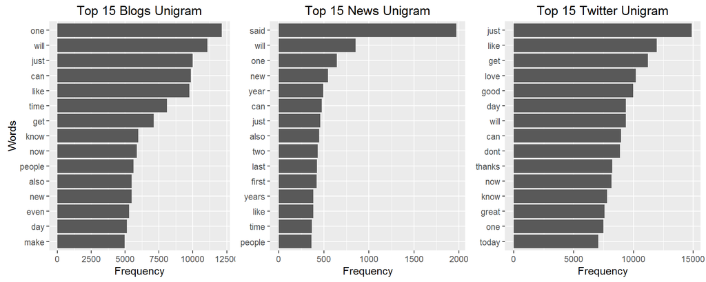

```r
nu_plot <- ggplot(news_uni_freq[1:15,], aes(Words, Frequency)) +
            geom_bar(stat = 'identity') + coord_flip() +
    ggtitle('Top 15 News Unigram') +  xlab(NULL)

bu_plot <- ggplot(blogs_uni_freq[1:15,], aes(Words, Frequency)) +
            geom_bar(stat = 'identity') + coord_flip() +
    ggtitle('Top 15 Blogs Unigram')

tu_plot <- ggplot(twitter_uni_freq[1:15,], aes(Words, Frequency)) +
            geom_bar(stat = 'identity') + coord_flip() +
    ggtitle('Top 15 Twitter Unigram') +  xlab(NULL)

grid.arrange(bu_plot, nu_plot, tu_plot, ncol=3)
```

### di.Gram and tri.Gram

The same steps has been followed to generate the 2-Gram and 3-Gram `TermDocumentMatrix`. We have passed the ng=2,3 in the `make_tdm` function. *stopwords* will be useful when forming the n gram matrix. So i have set the stopword as False.

```r
news_tdm_2gram <- make_tdm(news, ng=2, stopword = F)
blogs_tdm_2gram <- make_tdm(blogs, ng=2, stopword = F)
twitter_tdm_2gram <- make_tdm(twitter, ng=2, stopword = F)

news_tdm_3gram <- make_tdm(news, ng=3, stopword = F)
blogs_tdm_3gram <- make_tdm(blogs, ng=3, stopword = F)
twitter_tdm_3gram <- make_tdm(twitter, ng=3, stopword = F)
```

[figure not shown]

## Intresting Findings:

1. The use of the `row_sums` method from the slam package is more effecient than the rowSums from the base pack. And also noticed that the base rowSums is not working well on large tdm matrix.
2. In UniGram model, the top words like, love from twitter, said, people from News and one , can from blog are most unterstandable. Twitter is used for expressing love. News will often high what the leaders said about people.
3. The words which are Di gram are more ofter repeated in Tri Grams with stop words or the words that appear in Unigram model.

## Next steps:

1. Developing the working model of the text prediction and developing the data product in shinyapp. Since the final software will be launched in the Shinyserver, more optimization needs to be taken to reduce the memory usage and size.
2. Finding the good smoothing method and the evaluation model will help to obtain the above goal.